# Determinants of Income and Its Effects on Overall Health Status

Cindy Gao, Jack Han, Vidhi Patel

2022-12-22

# INTRODUCTION

The healthcare industry is one of the largest industries in the United States of America (USA), accounting for over 19.7% of the national GDP in 2020, and worth over $800 billion dollars in 2021. The USA on average invests almost twice as much in healthcare, than other countries. Yet, with all the money pouring in, the country has still below average health levels amongst the population. Specifically, the USA ranks last in healthcare quality and access. So the question becomes, where has all the money gone?

It turns out that the USA does indeed have a highly valuable healthcare industry, with advanced and state of the art technology. However, it is the highly uneven distribution and access to these services and healthcare tools, that creates such high disparity amongst the population. Societal inequality in a population has long been documented to be correlated with higher rates of health-related issues. In the United States, studies have found that high mortality rates and poor health is often associated with income inequality. Research also suggests that higher rates of income inequality are often found in communities with higher minority populations. Thus, to understand the state of inequality in a community, and in extension, the health of a community, one must examine the presence of minorities. Furthermore, it is equally important to take into account other known factors related to income inequality such as unemployment, education, resource access (i.e. vehicle, internet) and housing conditions.

This investigation seeks to dive deeper into the composition of income inequality of a community by studying the influence of indicators of minority presence, unemployment, education, resource access and housing conditions on income per capita. To fully assess the impact of these variables as well as income on health, this analysis will also examine how income per capita influences chronic disease presence.

# METHODS

## Data

For this investigation, the Minority Health SVI, by the U.S. Department of Health and Human Services Office of Minority Health, was used to conduct the research study. This dataset is an extension of the CDC/ATSDR SVI dataset. This dataset contains census level information, categorized on a geographical level in the USA, based on each area’s specific Federal Information Processing Standards (FIPS) code. The dataset is divided into four distinct social vulnerability categories; Socioeconomic Status, Household Composition & Disability, Minority Status & Language and Housing Type & Transportation. Additionally, this dataset provides two extra health vulnerability categories, which are Health Care Infrastructure & Access, and Medical Vulnerability.

For Socioeconomic Status, variables include per capita income level, employment levels, degree levels, and poverty indicator. For Household Composition & Disability, variables include one’s age range, disability status, and single parent status. For Minority Status & Language, variables include one’s ethnicity (American Indian/Alaska Native, Asian, African American, Native Hawaiian/Pacific Islander, Hispanic or Latinx and Some Other Race), and their English speaking levels (below/above “Very well” for native Spanish, Chinese, Vietnamese, Korean and Russian speakers). For Housing Type & Transportation, variables include their household statuses, the environment of the place they live (Multi-Unit Structures, Group Quarters, Mobile Home), whether there exists crowding, and whether they have vehicles or not. For Health Care Infrastructure & Access, the variables include the count of the numbers of hospitals, urgent care clinics, pharmacies, primary care physicians and health insurance of the people, in each geographic area. Lastly, for Medical Vulnerability, variables contain the count of the number of reported cardiovascular disease (CVD), chronic respiratory disease, obesity, diabetes and internet access across each geographic area.

## Goal

This investigation hopes to study whether one’s minority status has an effect on one’s overall health status. To do this, the income level per capita will be the bridge between these two vulnerabilities. Therefore, the implementation will first begin by studying whether one’s minority status has effects on income per capita levels, and then proceedingly, how does one’s income levels correlate (if any) to one’s overall health status. Thus for this investigation specifically, all variables were carefully selected to carry out this research plan. Roughly all variables from the Minority Health SVI dataset were used.

## Data Cleansing

The first step of this investigation is to configure a proper dataset to work with. First, there were many missing values in the dataset, represented by -999. Missing values are difficult to work with, therefore their values were changed to zeros, to facilitate the graphing, and model building components. Additionally, the dataset did not provide a proper overall health status level, therefore, to do this, a new “all_disease” variable was computed by summing up the cardiovascular disease, chronic respiratory disease, obesity, and diabetes numbers.

## Implementation

# RESULTS

## Influencers of Income

### Minority Population

To examine the impact of minority populations on income, we looked at two different sets of features. Our first set of features centered around language while our second set focused on ethnicity as a representation of minority populations.

#### Language:

From this model summary, a proper model can be formed as the following, and each model after this follows the same layout:

$$\hat{E\_PCI} = \hat{26862.10} -
\hat{511.50}(E\_SPAN) + \hat{414.30}(E\_CHIN) + \hat{129.20}(E\_VIET) +
\hat{427.18}(E\_KOR) + \hat{1083}(E\_RUS)$$

```
#>
#> Call:
#> lm(formula = svi_tb$E_PCI ~ log_transform(svi_tb$E_SPAN) + log_transform(svi_tb$E_CHIN) +
#>     log_transform(svi_tb$E_VIET) + log_transform(svi_tb$E_KOR) +
#>     log_transform(svi_tb$E_RUS))
#>
#> Residuals:
#>    Min     1Q Median     3Q    Max
#> -23921  -3666   -608   2988  37460
#>
#> Coefficients:
#>                              Estimate Std. Error t value Pr(>|t|)
#> (Intercept)                  26862.10     271.10  99.086  < 2e-16 ***
#> log_transform(svi_tb$E_SPAN)  -511.50      58.60  -8.729  < 2e-16 ***
#> log_transform(svi_tb$E_CHIN)   414.30      71.37   5.805 7.08e-09 ***
#> log_transform(svi_tb$E_VIET)   129.20      73.11   1.767   0.0773 .
#> log_transform(svi_tb$E_KOR)    427.18      81.45   5.244 1.67e-07 ***
#> log_transform(svi_tb$E_RUS)   1083.38      81.96  13.219  < 2e-16 ***
#> ---
#> Signif. codes:  0 '***' 0.001 '**' 0.01 '*' 0.05 '.' 0.1 ' ' 1
#>
#> Residual standard error: 5614 on 3136 degrees of freedom
#> Multiple R-squared:  0.262,  Adjusted R-squared:  0.2608
#> F-statistic: 222.6 on 5 and 3136 DF,  p-value: < 2.2e-16
```

It appears that only the presence of Spanish speakers who cannot speak English fluently has a negative correlation with income per capita (coefficient =-511.50). Other language speakers who cannot speak English fluently have a small but positive effect on income per capita. This means that despite not speaking English really well, all minorities included, except Spanish, seem to have a positive correlation with income per capita; this means that an increase in those numbers in minorities, despite their poor English skills, still increases their income levels. However, looking at the model, it can be seen that the increases are quite small.

#### Ethinicity:

```
#>
#> Call:
#> lm(formula = svi_tb$E_PCI ~ log_transform(svi_tb$E_AIAN) + log_transform(svi_tb$E_AFAM) +
#>     log_transform(svi_tb$E_NHPI) + log_transform(svi_tb$E_HISP) +
#>     log_transform(svi_tb$E_OTHER))
#>
#> Residuals:
#>    Min     1Q Median     3Q    Max
#> -30930  -3876   -640   2950  44129
#>
#> Coefficients:
#>                               Estimate Std. Error t value Pr(>|t|)
#> (Intercept)                   23629.59     507.35  46.575  < 2e-16 ***
#> log_transform(svi_tb$E_AIAN)     41.13      68.12   0.604 0.546006
#> log_transform(svi_tb$E_AFAM)   -478.61      53.81  -8.894  < 2e-16 ***
#> log_transform(svi_tb$E_NHPI)    697.64      71.75   9.724  < 2e-16 ***
#> log_transform(svi_tb$E_HISP)    493.33     136.96   3.602 0.000321 ***
#> log_transform(svi_tb$E_OTHER)   258.17     109.69   2.354 0.018649 *
#> ---
#> Signif. codes:  0 '***' 0.001 '**' 0.01 '*' 0.05 '.' 0.1 ' ' 1
#>
#> Residual standard error: 6106 on 3136 degrees of freedom
#> Multiple R-squared:  0.1272, Adjusted R-squared:  0.1258
#> F-statistic: 91.41 on 5 and 3136 DF,  p-value: < 2.2e-16
```

Looking at the summary, it can be seen that the number of people that identify as African American or Black is negatively associated with income per capita (coefficient = -478.67). In other words, communities with larger African American or Black populations may have a smaller income per capita compared to communities with smaller or negligent African American or Black populations. Interestingly, the number of people that identify as Hispanic or Latin(o) has an almost equal but positive correlation with income per capita.

#### Other Factors:

```
#>
#> Call:
#> lm(formula = svi_tb$E_PCI ~ log_transform(svi_tb$E_NOHSDP) +
#>     log_transform(svi_tb$E_UNEMP) + log_transform(svi_tb$E_NOVEH) +
#>     log_transform(svi_tb$E_SNGPNT) + log_transform(svi_tb$E_MUNIT))
#>
#> Residuals:
#>    Min     1Q Median     3Q    Max
#> -21700  -3178   -722   2229  41460
#>
#> Coefficients:
#>                                Estimate Std. Error t value Pr(>|t|)
#> (Intercept)                    33876.92     617.79  54.836  < 2e-16 ***
#> log_transform(svi_tb$E_NOHSDP) -3582.30     222.55 -16.096  < 2e-16 ***
#> log_transform(svi_tb$E_UNEMP)    502.66     209.36   2.401   0.0164 *
#> log_transform(svi_tb$E_NOVEH)   -983.65     213.59  -4.605 4.28e-06 ***
#> log_transform(svi_tb$E_SNGPNT)  1517.20     271.88   5.580 2.60e-08 ***
#> log_transform(svi_tb$E_MUNIT)   2351.54      91.18  25.791  < 2e-16 ***
#> ---
#> Signif. codes:  0 '***' 0.001 '**' 0.01 '*' 0.05 '.' 0.1 ' ' 1
#>
#> Residual standard error: 5352 on 3136 degrees of freedom
#> Multiple R-squared:  0.3293, Adjusted R-squared:  0.3282
#> F-statistic: 307.9 on 5 and 3136 DF,  p-value: < 2.2e-16
```

Evidently, persons aged 25+ with no high school diploma (coefficicent = -3582.80) and households with no vehicle available (coefficient =-983.65) are negatively correlated with income per capita. The positive correlation between larger housing structures and income per capita suggests that larger housing structures may signify the location of the community (i.e. city) rather than the housing affordability of the area.

## Health and Income

#### Combined Health Metric

To gauge the effect of income on health outcomes, we looked at the influence of income on the combined health metric as well as each of the factors of the metric individually. The combined health metric merges the death rates of cardiovascular and respiratory diseases as well as the total count of people with diabetes and obesity.

```
#>
#> Call:
#> lm(formula = svi_tb$all_diseases ~ svi_tb$E_PCI)
#>
#> Residuals:
#>    Min     1Q Median     3Q    Max
#> -26635  -4276    250   4390  35928
#>
#> Coefficients:
#>                Estimate Std. Error t value Pr(>|t|)
#> (Intercept)   6.205e+04  5.386e+02   115.2   <2e-16 ***
#> svi_tb$E_PCI -6.799e-01  1.937e-02   -35.1   <2e-16 ***
#> ---
#> Signif. codes:  0 '***' 0.001 '**' 0.01 '*' 0.05 '.' 0.1 ' ' 1
#>
#> Residual standard error: 7089 on 3140 degrees of freedom
#> Multiple R-squared:  0.2818, Adjusted R-squared:  0.2816
#> F-statistic:  1232 on 1 and 3140 DF,  p-value: < 2.2e-16
```

### Geographic Maps

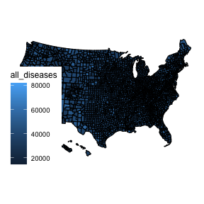

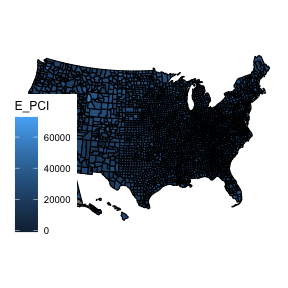

## Discussion

Based on investigation, regression models for predicting income reveal some important nuances about underlying drivers for income per capita and in extension social inequalities. When only considering minority status, high numbers of Spanish speakers with limited English proficiency negatively impacts income per capita. This confounds the fact that English proficiency among Spanish speakers has been associated with higher earnings. High numbers of African American/Black individuals in a community also negatively impacts income per capita. These findings suggest these groups may need to be targeted to decrease income inequality. Targeting here indicates various strategies proven to help with increasing economic welfare such as education policy. Other factors like persons aged 25+ with no high school diploma and households with no vehicle available also have a negative impact on income per capita. This intuitively makes sense intuitively, as lower education levels tend to have lower position, resulting in lower income levels. Additionally, people with lower number of cars or not cars, correlates to lower income levels, as vehicles are often viewed as a luxury. This means that those education, at least at the high school level, can be crucial in breaking certain barriers in income. It also signifies that vehicle access can be crucial in securing resources for achieving higher (or any) income.

## Limitations

The effects of minority status on the uneven wealth and quality healthcare distribution across the United States of America have been a long-discussed topic. As it can be seen, this is a large complex and intricate topic that involves many different factors. To successfully produce this research investigation, many of these aspects had to be simplified. Due to this, there may be some factors that may have been overlooked in the results.

First, despite a comprehensive dataset, there is still a limited number of available variables to use. For example, for minorities, only Spanish, Chinese, Vietnamese, Korean, and Russian were clearly identified, and the others are grouped into the “Others” group. This evidently shows that there is a lack of information, as there definitely are other minority groups that are not clearly identified in this dataset. Additionally, there are other extraneous factors that can influence one’s income status as well, such as, gender, and occupation.

Furthermore, there was no clear identification of the overall health levels across the country in the dataset, therefore a new one was produced using the total reported sum of CVD, chronic respiratory disease, obesity and diabetes. Although this gives a decent representative of the overall health levels, there are other indexes that exist, such as the incidence rate, which represents overall health levels. Additionally, despite all these being the top health issues in the country, it is far from the whole picture. For example, cancer is also one of the top diseases in the USA, but is left out of this study. Cancer is only one of many other diseases that were not accounted for in this study.

# CONCLUSION

All in all, social inequalities like income (as measured by income per capita) is influenced by a multitude of factors. While one may be compelled to group overarching themes such as minorities or education as determinants of these inequalities, our investigation reveals that identifying those on the lower end of a given measure may require more specificity. The effects of minority status on the uneven wealth and quality healthcare distribution across the United States of America have been a long-discussed topic. As it can be seen, this is a large complex and intricate topic that involves many different factors. To successfully produce this research investigation, many of these aspects had to be simplified. Due to this, there may be some factors that may have been overlooked in the results.

# REFERENCES

McLaughlin DK, Stokes CS. Income inequality and mortality in US counties: does minority racial concentration matter? American Journal of Public Health. 2002 Jan;92(1):99-104 Ray D, Linden M. Health, inequality and income: a global study using simultaneous model. Journal of Economic Structures. 2018 Dec;7(1):1-28. Schwartz A, Soifer D. The Value of English Proficiency to the United States Economy. December 2012. https://www.lexingtoninstitute.org/wp-content/uploads/2013/11/ValueOfEnglishProficiency.pdf Zhang S, Xiang W. Income gradient in health-related quality of life—The role of social networking time. International Journal For Equity In Health. 2019 Dec;18(1):1-0.